# Lifetime Wealth

Caro Buck

2/9/2021

## Lifetime Wealth + Race

For this week’s #TidyTuesday, I’m trying something new by using a Markdown doc to create my visualization. This week’s data looks at wealth inequities, especially by race, with data from the [Urban Institute](https://apps.urban.org/features/wealth-inequality-charts/) and US Census. I’m going to look at differences in retirement amounts, by race and year, with a custom/DIY ggplot2 theme.

Other things I learned about rendering markdowns in github; need to add a special output to make it render properly in github. ([Ref](https://stackoverflow.com/questions/39814916/how-can-i-see-output-of-rmd-in-github))

## Reading in the Data + Loading Libraries

```r
library(tidyverse)
retirement <- readr::read_csv('https://raw.githubusercontent.com/rfordatascience/tidytuesday/master/data/2021/2021-02-09/retirement.csv')
```

Let’s get a glimpse of the data for what we’ll be working with. How many races? How many years?

```r
retirement %>%
  glimpse()
```

```
## Rows: 30
## Columns: 3
## $ year       <dbl> 1989, 1989, 1989, 1992, 1992, 1992, 1995, 1995, 1995,…
## $ race       <chr> "White", "Black", "Hispanic", "White", "Black", "Hisp…
## $ retirement <dbl> 32649.430, 5954.398, 7121.722, 36637.760, 7798.197, 5…
```

```r
retirement %>% count(race)
```

```
## # A tibble: 3 x 2
##   race         n
##   <chr>    <int>
## 1 Black       10
## 2 Hispanic    10
## 3 White       10
```

```r
retirement %>% summary()
```

```
##       year          race             retirement
##  Min.   :1989   Length:30          Min.   :  5249
##  1st Qu.:1995   Class :character   1st Qu.: 15021
##  Median :2002   Mode  :character   Median : 21809
##  Mean   :2002                      Mean   : 41411
##  3rd Qu.:2010                      3rd Qu.: 44936
##  Max.   :2016                      Max.   :157884
```

## Now let’s get to plotting!

First, just a basic ggplot2 to see what we’re working with:

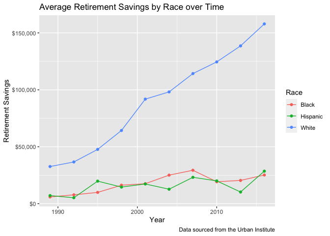

```r
retirement %>%
  ggplot(aes(x=year,y=retirement,color = race)) +
  geom_line() +
  geom_point() +
  scale_y_continuous(labels = scales::dollar) +
  labs(x='Year',y='Retirement Savings',color = 'Race',
       title = 'Average Retirement Savings by Race over Time',
       caption = 'Data sourced from the Urban Institute')
```

I think we can make this a *little* more exciting visually; let’s make a custom ggplot2 theme. I’ll start with the theme_bw(), since I tend to like that one and use it a lot for my plots.

Some of the helpful links for reference: [this](https://joeystanley.com/blog/custom-themes-in-ggplot2) and [this](https://www.andrewheiss.com/blog/2017/09/27/working-with-r-cairo-graphics-custom-fonts-and-ggplot/#:~:text=R%20and%20ggplot%20can%20create,font%20family%20for%20the%20plot).

Also, [this](https://github.com/hrbrmstr/hrbrthemes) is good reference for some pre-built themes from the hrbrthemes R package (if I’m looking for some variety in life).

What fonts are actually available on my computer? After some exploration, let’s use Copperplate for this exercise.

```r
library(systemfonts)
system_fonts()

theme_bougie <- function () {
    theme_bw(base_size=12, base_family="Copperplate") %+replace%
        theme(
            panel.background = element_rect(fill = 'darkseagreen1'),
            panel.border = element_rect(fill=NA,color = 'purple'),
            panel.grid = element_line(color = 'darkturquoise'),
            legend.position = 'bottom',
            legend.background = element_rect(fill = 'orange')
        )
}
```

Now let’s see how that theme looks on our chart:

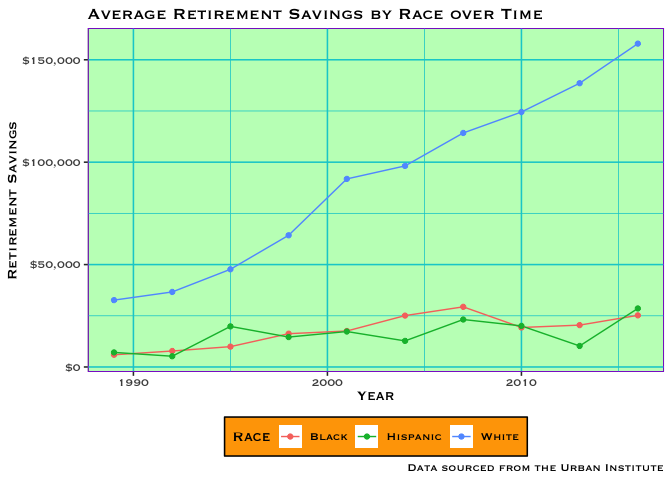

```r
retirement %>%
  ggplot(aes(x=year,y=retirement,color = race)) +
  geom_line() +
  geom_point() +
  scale_y_continuous(labels = scales::dollar) +
  labs(x='Year',y='Retirement Savings',color = 'Race',
       title = 'Average Retirement Savings by Race over Time',
       caption = 'Data sourced from the Urban Institute') +
  theme_bougie()
```

Ha! So it’s not the most beautiful (or necessarily color accessible), but it was fun to make something a little different and learn a new technique!